# Homework 02

## Question 1: Training and test error under a fixed design

**Show the solution code**

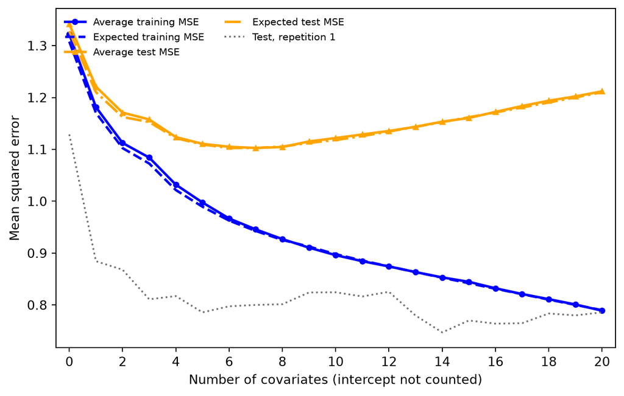

```python
import numpy as np
import pandas as pd
import matplotlib.pyplot as plt

rng = np.random.default_rng(43202)
X_all = rng.normal(loc=0.0, scale=1.0, size=(100, 20))
n, p = X_all.shape
X_m = np.column_stack((np.ones(n), X_all))
nsim = 200
sigma = 1.0
covariate_count = np.arange(p + 1)
beta = 0.4 ** np.sqrt(np.arange(1, p + 1))
meu = X_all @ beta
train_mse_decay = np.empty((nsim, p + 1))
test_mse_decay = np.empty((nsim, p + 1))

for k in range(nsim):
    y_train = meu + rng.normal(loc=0.0, scale=sigma, size=n)
    y_test = meu + rng.normal(loc=0.0, scale=sigma, size=n)

    y_hat = np.repeat(y_train.mean(), n)
    train_mse_decay[k, 0] = np.mean((y_train - y_hat) ** 2)
    test_mse_decay[k, 0] = np.mean((y_test - y_hat) ** 2)

    for m in range(1, p + 1):
        X_m = np.column_stack((np.ones(n), X_all[:, :m]))
        beta_hat = np.linalg.lstsq(X_m, y_train, rcond=None)[0]
        y_hat = X_m @ beta_hat
        train_mse_decay[k, m] = np.mean((y_train - y_hat) ** 2)
        test_mse_decay[k, m] = np.mean((y_test - y_hat) ** 2)

mean_train_mse_decay = train_mse_decay.mean(axis=0)
mean_test_mse_decay = test_mse_decay.mean(axis=0)

theory_train = np.empty(p + 1)
theory_test = np.empty(p + 1)
for m in range(p + 1):
    X_m = np.column_stack((np.ones(n), X_all[:, :m]))
    y_hat = X_m @ np.linalg.lstsq(X_m, meu, rcond=None)[0]
    bias_mse = np.mean((meu - y_hat) ** 2)
    theory_train[m] = bias_mse + 1 - (m + 1) / n
    theory_test[m] = bias_mse + 1 + (m + 1) / n

plt.figure(figsize=(7, 4.5))
plt.plot(covariate_count, mean_train_mse_decay, "o-", color="blue",
         linewidth=2, markersize=4, label="Average training MSE")
plt.plot(covariate_count, theory_train, "--", color="blue",
         linewidth=2, label="Expected training MSE")
plt.plot(covariate_count, mean_test_mse_decay, "^-", color="orange",
         linewidth=2, markersize=4, label="Average test MSE")
plt.plot(covariate_count, theory_test, "-.", color="orange",
         linewidth=2, label="Expected test MSE")
plt.plot(covariate_count, test_mse_decay[0], ":", color="0.45", lw=1.4,
         label="Test, repetition 1")
plt.xlabel("Number of covariates (intercept not counted)")
plt.ylabel("Mean squared error")
plt.xticks(np.arange(0, p + 1, 2))
plt.xlim(-0.5, p + 0.5)
plt.legend(frameon=False, ncol=2, fontsize=8, loc="upper left")
plt.tight_layout()
plt.show()
```

## Question 2: Prediction error at one target point

**Show the solution code**

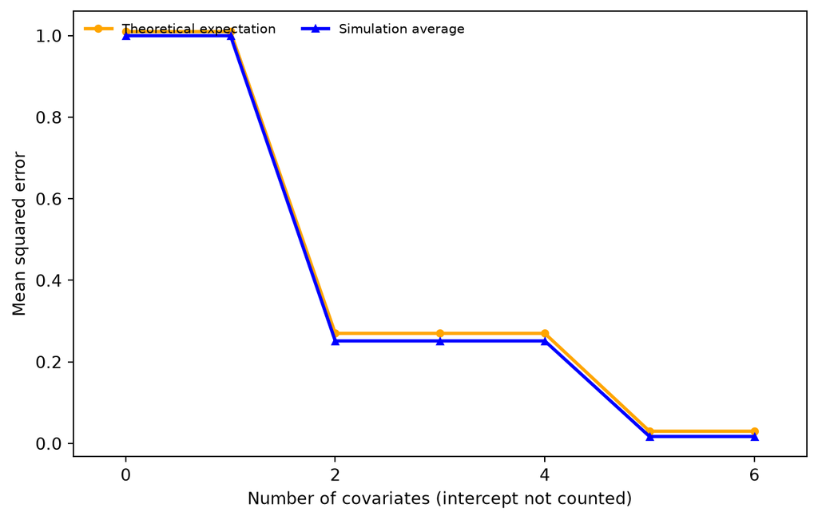

```python
import numpy as np
import pandas as pd
import matplotlib.pyplot as plt

n, p = 100, 6
i = np.arange(1, n + 1)[:, None]
j = np.arange(1, p + 1)[None, :]
X_all = np.sqrt(2) * np.cos(np.pi * j * (i - 0.5) / n)
beta = np.array([0.5, 0.5, 0.5, 0.5, 0.5, 0.5])
sigma = 1.0
covariate_count = np.arange(p + 1)
x0 = np.array([0, 1, 0, 0, 1, 0])
mu_0 = x0 @ beta
sq_bias = np.zeros(p + 1)
expected_sq_error = np.zeros(p + 1)

for m in range(p + 1):
    bias_sum = np.sum(x0[m:] * beta[m:])
    sq_bias[m] = bias_sum ** 2
    var_sum = 1.0 + np.sum(x0[:m] ** 2)
    variance = (sigma / n) * var_sum
    expected_sq_error[m] = sq_bias[m] + variance

rng = np.random.default_rng(43203)
nsim = 200
mu_hat_mu0 = np.empty((nsim, p + 1))
for k in range(nsim):
    y_train = X_all @ beta + rng.normal(loc=0.0, scale=sigma, size=n)
    for m in range(p + 1):
        beta_hat = np.linalg.lstsq(X_all, y_train, rcond=None)[0]
        mu_hat = x0[:m] @ beta_hat[:m]
        mu_hat_mu0[k, m] = (mu_hat - mu_0) ** 2

mean_mu_hat_mu0 = mu_hat_mu0.mean(axis=0)
plt.figure(figsize=(7, 4.5))
plt.plot(covariate_count, expected_sq_error, "o-", color="orange",
         linewidth=2, markersize=4, label="Theoretical expectation")
plt.plot(covariate_count, mean_mu_hat_mu0, "^-", color="blue",
         linewidth=2, markersize=4, label="Simulation average")
plt.xlabel("Number of covariates (intercept not counted)")
plt.ylabel("Mean squared error")
plt.xticks(np.arange(0, p + 1, 2))
plt.xlim(-0.5, p + 0.5)
plt.legend(frameon=False, ncol=2, fontsize=8, loc="upper left")
plt.tight_layout()
plt.show()
```

When an irrelevant local predictor with $x_0=0$ is added to the model, its coefficient-estimation noise does not impact the local prediction because its contribution is multiplied by zero: $b_j x_{0j}=0$.

## Question 3: The optimism correction

### Part a

The training residual is

$$\mathbf y-\mathbf H\mathbf y
=(\mathbf I_n-\mathbf H)\boldsymbol\mu
+(\mathbf I_n-\mathbf H)\boldsymbol\epsilon.$$

Let $\mathbf M=\mathbf I_n-\mathbf H$. Then $\mathbf M$ is symmetric and idempotent. Expanding the squared norm gives

$$\operatorname{MSE}_{\mathrm{train}}
=\frac{1}{n}\left(
B^2+2\boldsymbol\mu^{\mathsf T}\mathbf M\boldsymbol\epsilon
+\boldsymbol\epsilon^{\mathsf T}\mathbf M\boldsymbol\epsilon
\right).$$

The cross term has expectation zero. Also,

$$E(\boldsymbol\epsilon^{\mathsf T}\mathbf M\boldsymbol\epsilon\mid\mathbf X)
=\sigma^2\operatorname{tr}(\mathbf M)
=\sigma^2\{n-(p+1)\}.$$

Therefore,

$$E(\operatorname{MSE}_{\mathrm{train}}\mid\mathbf X)
=\frac{B^2}{n}+\sigma^2\left(1-\frac{p+1}{n}\right).$$

For the test response,

$$\mathbf y^*-\mathbf H\mathbf y
=(\mathbf I_n-\mathbf H)\boldsymbol\mu
+\boldsymbol\epsilon^*-\mathbf H\boldsymbol\epsilon.$$

The test-error noise is independent of the training noise, and the cross terms have expectation zero. Since $\operatorname{tr}(\mathbf H)=p+1$,

$$E\left(\lVert\boldsymbol\epsilon^*-\mathbf H\boldsymbol\epsilon\rVert_2^2\mid\mathbf X\right)
=n\sigma^2+(p+1)\sigma^2.$$

Thus,

$$E(\operatorname{MSE}_{\mathrm{test}}\mid\mathbf X)
=\frac{B^2}{n}+\sigma^2\left(1+\frac{p+1}{n}\right).$$

### Part b

The expected optimism is

$$E(\operatorname{MSE}_{\mathrm{test}}-\operatorname{MSE}_{\mathrm{train}}\mid\mathbf X)
=\frac{2(p+1)\sigma^2}{n}.$$

For $n=120$, $p=4$, $B^2/n=0.04$, and $\sigma^2=1$:

$$E(\operatorname{MSE}_{\mathrm{train}}\mid\mathbf X)
=0.04+1\left(1-\frac{5}{120}\right)=0.9983,$$

$$E(\operatorname{MSE}_{\mathrm{test}}\mid\mathbf X)
=0.04+1\left(1+\frac{5}{120}\right)=1.082,$$

and

$$E(\operatorname{MSE}_{\mathrm{test}}-\operatorname{MSE}_{\mathrm{train}}\mid\mathbf X)
=\frac{10}{120}=0.0833.$$

These are expected values over repeated samples. For one realized pair of responses, random variation can cause the test MSE to be smaller than the training MSE.

### Part c

$$\widehat{\operatorname{MSE}}_{\mathrm{test}}
=\frac{116.4+2(4+1)(0.96)}{120}=1.05.$$

$$C_p=\frac{116.4}{0.96}-120+2(4+1)=11.25.$$

Their relationship is

$$\widehat{\operatorname{MSE}}_{\mathrm{test}}
=\frac{\widehat\sigma^2(C_p+n)}{n}.$$

When $n$ and $\widehat\sigma^2$ are common to all candidate models, this is an increasing transformation, so minimizing $C_p$ is equivalent to minimizing the corrected test MSE.

## Question 4: Comparing Mallows’ $C_p$, AIC, and BIC

**Show the solution code**

```python
import numpy as np
import pandas as pd
import matplotlib.pyplot as plt

diabetes = pd.read_csv("week-02/data/diabetes.csv").iloc[:370]
predictor_names = [name for name in diabetes.columns if name != "y"]
X_raw = diabetes[predictor_names].to_numpy()
y = diabetes["y"].to_numpy()
n = len(diabetes)
p_full = len(predictor_names)
X_null = np.ones((n, 1))
X_full = np.column_stack((np.ones(n), X_raw))

beta_hat_null = np.linalg.lstsq(X_null, y, rcond=None)[0]
beta_hat_full = np.linalg.lstsq(X_full, y, rcond=None)[0]
residuals_null = y - X_null @ beta_hat_null
residuals_full = y - X_full @ beta_hat_full
rss_null = float(residuals_null @ residuals_null)
rss_full = float(residuals_full @ residuals_full)
parameter_count_full = p_full + 1
sigma2_hat = rss_full / (n - parameter_count_full)

A = ["bmi", "bp", "s5", "sex", "s1", "s2", "s4"]
A_values = diabetes[A].to_numpy()
A_full = np.column_stack((np.ones(n), A_values))
beta_full_A = np.linalg.lstsq(A_full, y, rcond=None)[0]
residuals_full_A = y - A_full @ beta_full_A
rss_full_A = float(residuals_full_A @ residuals_full_A)
parameter_count_full_A = A_full.shape[1]

B = A + ["s6"]
B_values = diabetes[B].to_numpy()
B_full = np.column_stack((np.ones(n), B_values))
beta_full_B = np.linalg.lstsq(B_full, y, rcond=None)[0]
residuals_full_B = y - B_full @ beta_full_B
rss_full_B = float(residuals_full_B @ residuals_full_B)
parameter_count_full_B = B_full.shape[1]

print("RSS full model:", rss_full)
print("Sigma^2 hat full model:", sigma2_hat)
print("RSS full A:", rss_full_A)
print("RSS full B:", rss_full_B)

Cp_A = rss_full_A / sigma2_hat - n + 2 * parameter_count_full_A
BIC_A = n * np.log(rss_full_A / n) + np.log(n) * parameter_count_full_A
AIC_A = n * np.log(rss_full_A / n) + 2 * parameter_count_full_A
Cp_B = rss_full_B / sigma2_hat - n + 2 * parameter_count_full_B
BIC_B = n * np.log(rss_full_B / n) + np.log(n) * parameter_count_full_B
AIC_B = n * np.log(rss_full_B / n) + 2 * parameter_count_full_B

print("Cp A:", Cp_A)
print("BIC A:", BIC_A)
print("AIC A:", AIC_A)
print("Cp B:", Cp_B)
print("BIC B:", BIC_B)
print("AIC B:", AIC_B)

fit_gain = n * np.log(rss_full_A / rss_full_B)
cp_gain = (rss_full_A - rss_full_B) / sigma2_hat
print("AIC and BIC fit term:", fit_gain)
print("Cp improvement:", cp_gain)
```

```
RSS full model: 1089451.7212190419
Sigma^2 hat full model: 3034.6844602201722
RSS full A: 1098908.5656498766
RSS full B: 1089717.0567997107
Cp A: 8.116252959672977
BIC A: 3005.9482838558592
AIC A: 2974.640259810753
Cp B: 7.087434322792717
BIC B: 3008.754011613133
AIC B: 2973.5324845623886
AIC and BIC fit term: 3.107775248364385
Cp improvement: 3.028818636880295
```

## Question 5: Validation and final test data

### Part a

The misuse begins at step 2 because the final test set is used to compare the candidate models and select $m$. Reporting the minimum of the eleven test MSE values gives an optimistic estimate of future prediction error because the minimum is likely to benefit from random variation.

### Part b

1. Split the training data into five folds.
2. For each candidate predictor count, compute its average MSE across the five validation folds and select the predictor count that minimizes the average five-fold error.
3. Refit the selected model using all the training observations.
4. Use the final test data once to evaluate the selected model.

### Part c

The eleven test MSE values and the fact that the smallest one was selected can be reported transparently, but the minimum should not be presented as an untouched final assessment. A new independent batch of test data, or genuinely future observations, is needed for a new final evaluation.

## Reference

James, Witten, Hastie, Tibshirani, and Taylor, *An Introduction to Statistical Learning*, Chapters 3, 5, and 6.